# ODE integration and sensitivity analysis

## SIR model

The SIR model describes the evolution of a disease in a population.

$$ \begin{cases} \frac{dS}{dt} &= -\beta \frac{S I}{N} \\ \frac{dI}{dt} &= \beta \frac{S I}{N} - \gamma I \\ \frac{dR}{dt} &= \gamma I \end{cases} $$

Where:

- $S(t)$ = Susceptible individuals at time $t$
- $I(t)$ = Infected individuals at time $t$
- $R(t)$ = Recovered individuals at time $t$
- $\beta$ = Transmission rate
- $\gamma$ = Recovery rate
- $N$ = Total population (constant, $N = S + I + R$)

## Key Assumptions:

1. Homogeneous mixing
2. No birth or death
3. Immunity after recovery

We will represent all the populations using normalized concentrations.

```python
def sir(t, state, a, b):
    S, I, R = state
    dSdt = - a*S*I
    dIdt = + a*S*I - b*I
    dRdt = + b*I
    return dSdt, dIdt, dRdt
```

```python
# initial condition
state0 = (0.999, 0.001, 0.0)

# time interval
t_span = (0, 10)

# time points at which to evaluate the solution
t_eval = np.linspace(t_span[0], t_span[1], 100)

# parameters
a, b = 5, 1  # beta, gamma

# solve ODE
sol = solve_ivp(sir, t_span, state0, args=(a, b), method='RK45',
                t_eval=t_eval)
```

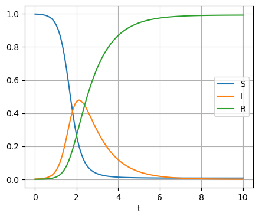

```python
plt.figure(figsize=(5,4))
plt.plot(sol.t, sol.y[0], label='S')
plt.plot(sol.t, sol.y[1], label='I')
plt.plot(sol.t, sol.y[2], label='R')
plt.grid(True)
plt.xlabel('t')
plt.legend(loc='best')
plt.show()
```

What happens if we change the value of one of the parameters?

```python
a = 5
b = 1
b_range = np.random.normal(b, b*0.1, 50)

# time interval
t_span = (0, 5)

# initial condition
state0 = (0.999, 0.001, 0.0)  # S, I, R

# time points at which to evaluate the solution
t_eval = np.linspace(t_span[0], t_span[1], 100)

results = []
cols = ['S', 'I', 'R']
idx = 0
for bi in b_range:
    sols = solve_ivp(sir, t_span, state0, args=(a, bi), method='RK45',
                     t_eval=t_eval)
    res_i_df = create_df(np.transpose(sols.y), cols, a=a, b=bi, r0=a/bi,
                         time=sols.t, simulation_run=idx, type='varying b')
    results.append(res_i_df)
    idx = idx + 1
results = pd.concat(results, ignore_index=True)
```

```python
results
```

|  | S | I | R | a | b | r0 | time | simulation_run | type |
| --- | --- | --- | --- | --- | --- | --- | --- | --- | --- |
| 0 | 0.999000 | 0.001000 | 0.000000 | 5 | 1.054451 | 4.741805 | 0.000000 | 0 | varying b |
| 1 | 0.998721 | 0.001220 | 0.000059 | 5 | 1.054451 | 4.741805 | 0.050505 | 0 | varying b |
| 2 | 0.998380 | 0.001489 | 0.000131 | 5 | 1.054451 | 4.741805 | 0.101010 | 0 | varying b |
| 3 | 0.997965 | 0.001816 | 0.000219 | 5 | 1.054451 | 4.741805 | 0.151515 | 0 | varying b |
| 4 | 0.997459 | 0.002215 | 0.000325 | 5 | 1.054451 | 4.741805 | 0.202020 | 0 | varying b |
| ... | ... | ... | ... | ... | ... | ... | ... | ... | ... |
| 4995 | 0.010233 | 0.052705 | 0.937062 | 5 | 1.023915 | 4.883217 | 4.797980 | 49 | varying b |
| 4996 | 0.010101 | 0.050178 | 0.939722 | 5 | 1.023915 | 4.883217 | 4.848485 | 49 | varying b |
| 4997 | 0.009977 | 0.047770 | 0.942254 | 5 | 1.023915 | 4.883217 | 4.898990 | 49 | varying b |
| 4998 | 0.009860 | 0.045476 | 0.944664 | 5 | 1.023915 | 4.883217 | 4.949495 | 49 | varying b |
| 4999 | 0.009750 | 0.043291 | 0.946959 | 5 | 1.023915 | 4.883217 | 5.000000 | 49 | varying b |

5000 rows × 9 columns

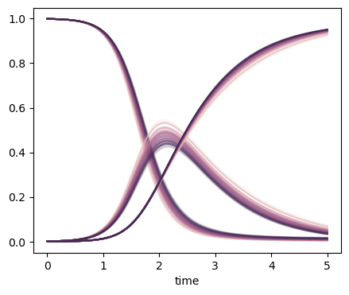

```python
args = dict(data=results, estimator=None, units='simulation_run',
            alpha=0.25, hue='b', legend=False)
plt.figure(figsize=(5,4))
sns.lineplot(x="time", y='S', **args).set(ylabel='')
sns.lineplot(x="time", y='I', **args).set(ylabel='')
sns.lineplot(x="time", y='R', **args).set(ylabel='')
plt.show()
```

```python
a = 5
b = 1
a_range = np.random.normal(a, a*0.1, 50)

# time interval
t_span = (0, 5)  # days

# initial condition
state0 = (0.999, 0.001, 0.0)  # S, I, R

# time points at which to evaluate the solution
t_eval = np.linspace(t_span[0], t_span[1], 100)

results = []
cols = ['S', 'I', 'R']
idx = 0
for ai in a_range:
    sols = solve_ivp(sir, t_span, state0, args=(ai, b), method='RK45',
                     t_eval=t_eval)
    res_i_df = create_df(np.transpose(sols.y), cols, a=ai, b=b, r0=ai/b,
                         time=sols.t, simulation_run=idx, type='varying a')
    results.append(res_i_df)
    idx = idx + 1
results = pd.concat(results, ignore_index=True)
```

```python
results
```

|  | S | I | R | a | b | r0 | time | simulation_run | type |
| --- | --- | --- | --- | --- | --- | --- | --- | --- | --- |
| 0 | 0.999000 | 0.001000 | 0.000000 | 4.814335 | 1 | 4.814335 | 0.000000 | 0 | varying a |
| 1 | 0.998732 | 0.001212 | 0.000056 | 4.814335 | 1 | 4.814335 | 0.050505 | 0 | varying a |
| 2 | 0.998408 | 0.001469 | 0.000123 | 4.814335 | 1 | 4.814335 | 0.101010 | 0 | varying a |
| 3 | 0.998014 | 0.001781 | 0.000205 | 4.814335 | 1 | 4.814335 | 0.151515 | 0 | varying a |
| 4 | 0.997539 | 0.002157 | 0.000304 | 4.814335 | 1 | 4.814335 | 0.202020 | 0 | varying a |
| ... | ... | ... | ... | ... | ... | ... | ... | ... | ... |
| 4995 | 0.003360 | 0.037855 | 0.958784 | 5.947445 | 1 | 5.947445 | 4.797980 | 49 | varying a |
| 4996 | 0.003324 | 0.036028 | 0.960648 | 5.947445 | 1 | 5.947445 | 4.848485 | 49 | varying a |
| 4997 | 0.003289 | 0.034289 | 0.962422 | 5.947445 | 1 | 5.947445 | 4.898990 | 49 | varying a |
| 4998 | 0.003256 | 0.032634 | 0.964110 | 5.947445 | 1 | 5.947445 | 4.949495 | 49 | varying a |
| 4999 | 0.003225 | 0.031057 | 0.965718 | 5.947445 | 1 | 5.947445 | 5.000000 | 49 | varying a |

5000 rows × 9 columns

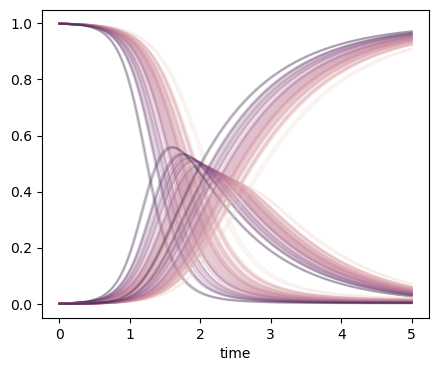

```python
args = dict(data=results, estimator=None, units='simulation_run',
            alpha=0.25, hue='a', legend=False)
plt.figure(figsize=(5,4))
sns.lineplot(x="time", y='S', **args).set(ylabel='')
sns.lineplot(x="time", y='I', **args).set(ylabel='')
sns.lineplot(x="time", y='R', **args).set(ylabel='')
plt.show()
```

```python
# parameters
a, b = 5, 1
pe = 0.1

results = []
cols = ['S', 'I', 'R']

# randomly generate 50 normally distributed values of a around the value a=5
a_range = np.random.normal(a, a*pe, 50)
idx = 0
for ai in a_range:
    sols = solve_ivp(sir, t_span, state0, args=(ai, b), method='RK45',
                     t_eval=t_eval)
    res_i_df = create_df(np.transpose(sols.y), cols, a=ai, b=b, r0=ai/b,
                         time=sols.t, simulation_run=idx, type='varying a')
    results.append(res_i_df)
    idx = idx + 1

# randomly generate 50 normally distributed values of b around the value b=1
b_range = np.random.normal(b, b*pe, 50)
idx = 0
for bi in b_range:
    sols = solve_ivp(sir, t_span, state0, args=(a, bi), method='RK45',
                     t_eval=t_eval)
    res_i_df = create_df(np.transpose(sols.y), cols, a=a, b=bi, r0=a/bi,
                         time=sols.t, simulation_run=idx, type='varying b')
    results.append(res_i_df)
    idx = idx + 1

results = pd.concat(results, ignore_index=True)
```

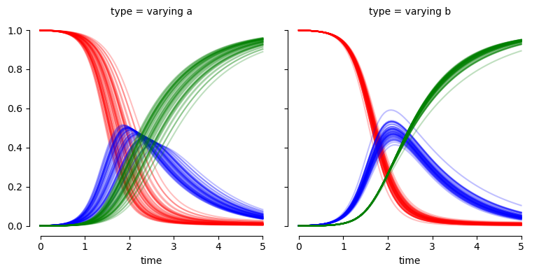

```python
fg = sns.FacetGrid(data=results, col='type', sharex=False, height=4,
                   legend_out=False)
fg.map_dataframe(sns.lineplot, x="time", y='S', estimator=None,
                 units='simulation_run', alpha=0.25, color='r')
fg.map_dataframe(sns.lineplot, x="time", y='I', estimator=None,
                 units='simulation_run', alpha=0.25, color='b')
fg.map_dataframe(sns.lineplot, x="time", y='R', estimator=None,
                 units='simulation_run', alpha=0.25, color='g')
fg.set(ylabel=None)
sns.despine(fg.fig, trim=True)
```

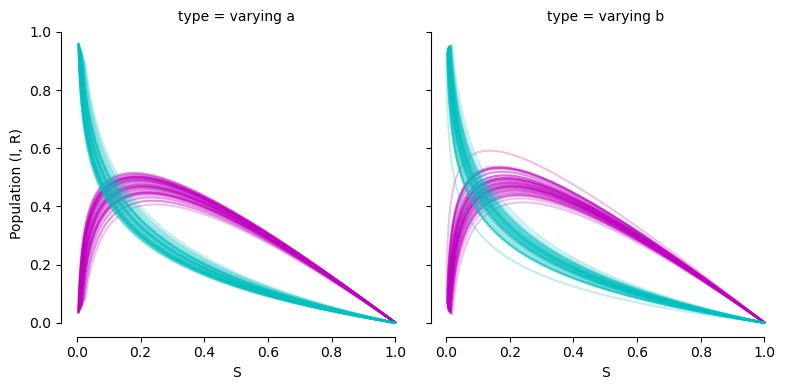

```python
fg = sns.FacetGrid(data=results, col='type', height=4)
fg.map_dataframe(sns.lineplot, x='S', y='I', estimator=None,
                 units='simulation_run', alpha=0.25, color='m')
fg.map_dataframe(sns.lineplot, x='S', y='R', estimator=None,
                 units='simulation_run', alpha=0.25, color='c')
fg.set_axis_labels('S', 'Population (I, R)')
sns.despine(fg.fig, trim=True)
```

## Sampling with noise

Sampling with noise is a powerful approach for understanding how measurement noise or uncertainty in the data affects parameter estimation in models like ODEs.

This can be done by:

- Introducing noise to the model (e.g., by adding Gaussian noise).
- Fitting the model to these noisy data points.
- Observing the covariation between the parameters after fitting the model, or how the fitted parameters change when there is noise in the data.

Let's consider the logistic growth model.

```python
def logistic(t, y, r, k):
    dydt = r*y*(1 - y/k)
    return dydt
```

```python
# initial condition
y0 = [0.1]

# time interval
t_span = (0, 1)

# time points at which to evaluate the solution
t_eval = np.linspace(t_span[0], t_span[1], 100)

# parameters
r = 10
k = 1

# solve ODE
sol = solve_ivp(logistic, t_span, y0, args=(r, k), method='RK45',
                t_eval=t_eval)
```

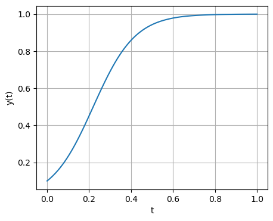

```python
plt.figure(figsize=(5,4))
plt.plot(sol.t, sol.y[0])
plt.xlabel('t')
plt.ylabel('y(t)')
plt.grid(True)
plt.show()
```

Let's add gaussian noise to our system.

To this end, we can use the `rvs` function from `scipy.stats`.

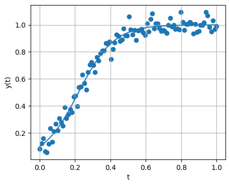

```python
import scipy.stats as st

y_hat_normal = st.norm.rvs(loc=sol.y[0], scale=0.05)

plt.figure(figsize=(5,4))
plt.plot(sol.t, sol.y[0])
plt.scatter(sol.t, y_hat_normal)
plt.xlabel('t')
plt.ylabel('y(t)')
plt.grid(True)
plt.show()
```

## Fitting procedure

To fit the model to these noisy data points, we will use the `curve_fit` function from `scipy.optimize`, that will give us an estimate of the parameters and their correlations.

To do this, it takes a function that, given the x values and a set of parameters, it gives the prediction.

First of all, let's see how it works in the simple case of a linear regression.

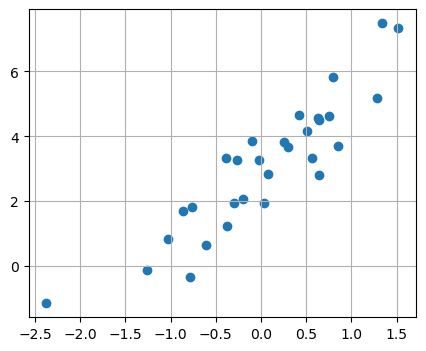

```python
from scipy.optimize import curve_fit

x = np.random.randn(30)
y = 2*x + 3 + np.random.randn(30)*0.8

plt.figure(figsize=(5,4))
plt.scatter(x, y)
plt.grid(True)
plt.show()
```

```python
def linear_fit(xdata, m, q):
    return m*xdata + q

p_avg, p_cov = curve_fit(linear_fit, x, y, p0=[1, 0])
```

```python
p_avg
```

```
array([2.20458608, 3.00248897])
```

```python
p_cov
```

```
array([[ 0.03755309, -0.00160552],
       [-0.00160552,  0.02615037]])
```

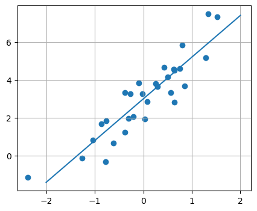

```python
x_values = np.linspace(-2, 2, 51)
y_hat = linear_fit(x_values, *p_avg)

plt.figure(figsize=(5,4))
plt.scatter(x, y)
plt.plot(x_values, y_hat)
plt.grid(True)
plt.show()
```

## How to visualize uncertainty?

- normal sampling
- 95% quantiles representation

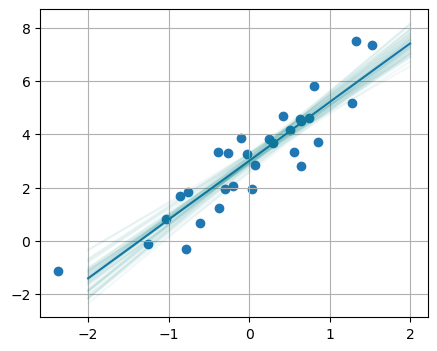

```python
p_seq = st.multivariate_normal.rvs(mean=p_avg, cov=p_cov, size=50)
x_base = np.linspace(-2, 2, 51)
y_hat = linear_fit(x_base, *p_avg)

plt.figure(figsize=(5,4))
plt.scatter(x, y)
plt.plot(x_base, y_hat)
plt.grid(True)

for params in p_seq:
    y_hat = linear_fit(x_base, *params)
    plt.plot(x_base, y_hat, color='teal', alpha=0.05)
```

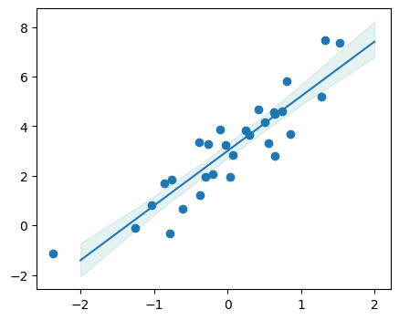

```python
from scipy.stats.mstats import mquantiles

p_seq = st.multivariate_normal.rvs(mean=p_avg, cov=p_cov, size=50)
x_base = np.linspace(-2, 2, 101)
y_hat = linear_fit(x_base, *p_avg)

plt.figure(figsize=(5,4))
plt.scatter(x, y)
plt.plot(x_base, y_hat)
y_hat = [linear_fit(x_base, *params) for params in p_seq]
y_hat = np.stack(y_hat)

p_low, p_top = mquantiles(y_hat, prob=[0.025, 0.975], axis=0)
plt.fill_between(x_base, p_low, p_top, alpha=0.1, color='teal')
plt.show()
```

```python
def logistic_fit(t_eval, r, k):
    y0 = [0.1]
    sol = solve_ivp(logistic, t_span, y0, args=(r, k), method='RK45',
                    t_eval=t_eval)
    return sol.y[0]

p_avg, p_cov = curve_fit(logistic_fit, t_eval, y_hat_normal, p0=[1, 0.1])
```

```python
p_avg
```

```
array([10.0156774 ,  0.99823568])
```

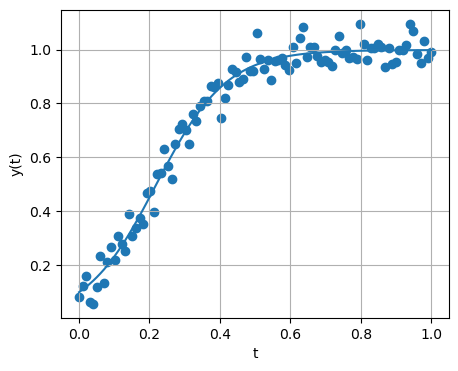

```python
y_fit = logistic_fit(t_eval, *p_avg)

plt.figure(figsize=(5,4))
plt.scatter(t_eval, y_hat_normal)
plt.plot(t_eval, y_fit)
plt.xlabel('t')
plt.ylabel('y(t)')
plt.grid(True)
plt.show()
```

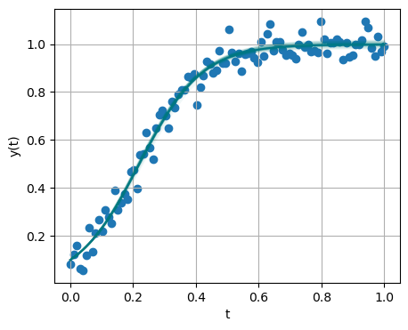

```python
p_seq = st.multivariate_normal.rvs(mean=p_avg, cov=p_cov, size=50)

plt.figure(figsize=(5,4))
plt.scatter(t_eval, y_hat_normal)
plt.plot(t_eval, y_fit)
plt.xlabel('t')
plt.ylabel('y(t)')
plt.grid(True)
for params in p_seq:
    y_hat_ = logistic_fit(t_eval, *params)
    plt.plot(t_eval, y_hat_, color='teal', alpha=0.05)
plt.show()
```

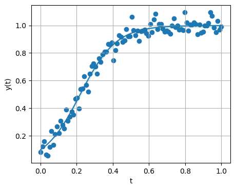

```python
p_seq = st.multivariate_normal.rvs(mean=p_avg, cov=p_cov, size=50)

plt.figure(figsize=(5,4))
plt.scatter(t_eval, y_hat_normal)
plt.plot(t_eval, y_fit)
plt.xlabel('t')
plt.ylabel('y(t)')
plt.grid(True)
y_hat_2 = [logistic_fit(t_eval, *params) for params in p_seq]
y_hat_2 = np.stack(y_hat_2)

p_low, p_top = mquantiles(y_hat_2, prob=[0.025, 0.975], axis=0)
plt.fill_between(t_eval, p_low, p_top, alpha=0.1, color='teal')
plt.show()
```

## Exercise

Consider the simple ODE shown as first example today:

$$ \frac{dy}{dt} = -ky $$

with parameter $k=0.4$ and initial condition $y_{0}=6$.

- Apply the two methods seen today to study the system.
- How would the results change if random samples were generated using the Van der Corput sequence?